# Stat 300 Homework 6

Tianjun

This homework is based on exercises from Chapters 3 and 4 in The Stat2 textbook. You may need to read the relevant problems in the text in order to complete this assignment. Write your answers and include your notes in this document, and submit as a pdf online in the Canvas HW Quiz.

**TASK** load all the packages that we are likely to need for this assignment:

New package: HH

# 1. Major League baseball

The **MLBStandings2016** dataset records many variables for Major League Baseball (MLB) teams from the 2016 regular season. In this exercise, you’ll consider models with four variables to predict winning percentages (*WinPct*) using any of the predictors except *Wins* and *Losses* - Those would make it too easy! Don’t worry if you are unfamiliar with baseball terminology as some of the acronyms for variable names have little meaning. Although knowledge of the context for data is often helpful for choosing good models, you should use software to build the models requested in this exercise rather than using specific baseball knowledge.

**TASK 1.0** Load the dataset.

```r
data("MLBStandings2016")
MLBStandings2016 <- MLBStandings2016 %>%
  dplyr::select(-Team, -Wins, -Losses)
```

**TASK 1.1** Use forward selection until you have a four-predictor model for *WinPct*. You may need to adjust the criteria if the procedure won’t give sufficient steps initially. Write down the predictors in this model and its R-squared value.

```r
# Fit the base model with only the intercept
base_model <- lm(WinPct ~ 1, data = MLBStandings2016)

# Perform forward selection
forward_model <- step(base_model, direction = "forward", scope = list(lower = ~1, upper = ~. - 1), trace = 1)
```

```
Start:  AIC=-161.94
WinPct ~ 1
```

```r
# Display the summary of the final model
model_summary <- summary(forward_model)
print(model_summary)
```

```
Call:
lm(formula = WinPct ~ 1, data = MLBStandings2016)

Residuals:
      Min        1Q    Median        3Q       Max
-0.136033 -0.058783  0.009467  0.045967  0.139967

Coefficients:
            Estimate Std. Error t value Pr(>|t|)
(Intercept)  0.50003    0.01208   41.39   <2e-16 ***
---
Signif. codes:  0 ‘***’ 0.001 ‘**’ 0.01 ‘*’ 0.05 ‘.’ 0.1 ‘ ’ 1

Residual standard error: 0.06618 on 29 degrees of freedom
```

```r
# Display the R-squared value
cat("R-squared value:", model_summary$r.squared, "\n")
```

```
R-squared value: 0
```

**TASK 1.2** Use backward elimination until you have a four-predictor model for *WinPct*. You may need to adjust the criteria if the procedure stops too soon to continue eliminating predictors. Write down the predictors in this model and its R-squared value.

```r
# Fit the full model with all predictors
full_model <- lm(WinPct ~ ., data = MLBStandings2016)

# Perform backward elimination
backward_model <- step(full_model, direction = "backward", trace = 1)
```

```
Start:  AIC=-221.74
WinPct ~ League + BattingAverage + Runs + Hits + HR + Doubles +
    Triples + RBI + SB + OBP + SLG + ERA + HitsAllowed + Walks +
    StrikeOuts + Saves + WHIP

                 Df Sum of Sq       RSS     AIC
- StrikeOuts      1 0.0000788 0.0056509 -223.31
- Doubles         1 0.0001017 0.0056738 -223.19
- SLG             1 0.0001722 0.0057442 -222.82
- HR              1 0.0001862 0.0057583 -222.75
- SB              1 0.0002287 0.0058008 -222.53
- Triples         1 0.0002453 0.0058174 -222.44
<none>                        0.0055721 -221.74
- League          1 0.0004543 0.0060264 -221.38
- BattingAverage  1 0.0006288 0.0062009 -220.53
- ERA             1 0.0007122 0.0062843 -220.13
- Hits            1 0.0010631 0.0066352 -218.50
- RBI             1 0.0010634 0.0066355 -218.50
- HitsAllowed     1 0.0011530 0.0067251 -218.09
- OBP             1 0.0014924 0.0070644 -216.62
- Walks           1 0.0015276 0.0070996 -216.47
- WHIP            1 0.0016088 0.0071809 -216.13
- Runs            1 0.0019692 0.0075413 -214.66
- Saves           1 0.0034260 0.0089980 -209.36

Step:  AIC=-223.31
WinPct ~ League + BattingAverage + Runs + Hits + HR + Doubles +
    Triples + RBI + SB + OBP + SLG + ERA + HitsAllowed + Walks +
    Saves + WHIP

                 Df Sum of Sq       RSS     AIC
- Doubles         1 0.0001275 0.0057784 -224.65
- SLG             1 0.0002171 0.0058680 -224.18
- HR              1 0.0002253 0.0058762 -224.14
- Triples         1 0.0002954 0.0059462 -223.79
- SB              1 0.0003506 0.0060014 -223.51
<none>                        0.0056509 -223.31
- League          1 0.0006868 0.0063377 -221.87
- ERA             1 0.0007220 0.0063729 -221.71
- BattingAverage  1 0.0007442 0.0063950 -221.60
```

[output cut: 16 more lines]

```
- SB              1 0.0004116 0.0061900 -224.58
- League          1 0.0005679 0.0063463 -223.83
- ERA             1 0.0006172 0.0063955 -223.60
- SLG             1 0.0007378 0.0065161 -223.04
- RBI             1 0.0008685 0.0066469 -222.44
- HR              1 0.0009267 0.0067050 -222.18
- Triples         1 0.0011238 0.0069022 -221.31
- OBP             1 0.0016571 0.0074355 -219.08
- Runs            1 0.0017656 0.0075439 -218.65
- HitsAllowed     1 0.0021045 0.0078828 -217.33
- Walks           1 0.0025102 0.0082885 -215.82
- WHIP            1 0.0029933 0.0087717 -214.12
- Saves           1 0.0032623 0.0090406 -213.22
- Hits            1 0.0036865 0.0094648 -211.84
- BattingAverage  1 0.0057970 0.0115753 -205.80
```

```r
# Manually control the backward elimination to ensure only four predictors remain
while (length(coef(backward_model)) > 5) {  # 5 because it includes the intercept
  current_model <- backward_model
  backward_model <- step(backward_model, direction = "backward", trace = 1, steps = 1)

  # Break if no predictors were removed in the last step
  if (identical(current_model, backward_model)) {
    break
  }
}
```

```
Start:  AIC=-224.65
WinPct ~ League + BattingAverage + Runs + Hits + HR + Triples +
    RBI + SB + OBP + SLG + ERA + HitsAllowed + Walks + Saves +
    WHIP

                 Df Sum of Sq       RSS     AIC
<none>                        0.0057784 -224.65
- SB              1 0.0004116 0.0061900 -224.58
- League          1 0.0005679 0.0063463 -223.83
- ERA             1 0.0006172 0.0063955 -223.60
- SLG             1 0.0007378 0.0065161 -223.04
- RBI             1 0.0008685 0.0066469 -222.44
- HR              1 0.0009267 0.0067050 -222.18
- Triples         1 0.0011238 0.0069022 -221.31
- OBP             1 0.0016571 0.0074355 -219.08
- Runs            1 0.0017656 0.0075439 -218.65
- HitsAllowed     1 0.0021045 0.0078828 -217.33
- Walks           1 0.0025102 0.0082885 -215.82
- WHIP            1 0.0029933 0.0087717 -214.12
- Saves           1 0.0032623 0.0090406 -213.22
- Hits            1 0.0036865 0.0094648 -211.84
- BattingAverage  1 0.0057970 0.0115753 -205.80
Start:  AIC=-224.65
WinPct ~ League + BattingAverage + Runs + Hits + HR + Triples +
    RBI + SB + OBP + SLG + ERA + HitsAllowed + Walks + Saves +
    WHIP

                 Df Sum of Sq       RSS     AIC
<none>                        0.0057784 -224.65
- SB              1 0.0004116 0.0061900 -224.58
- League          1 0.0005679 0.0063463 -223.83
- ERA             1 0.0006172 0.0063955 -223.60
- SLG             1 0.0007378 0.0065161 -223.04
- RBI             1 0.0008685 0.0066469 -222.44
- HR              1 0.0009267 0.0067050 -222.18
- Triples         1 0.0011238 0.0069022 -221.31
- OBP             1 0.0016571 0.0074355 -219.08
- Runs            1 0.0017656 0.0075439 -218.65
- HitsAllowed     1 0.0021045 0.0078828 -217.33
- Walks           1 0.0025102 0.0082885 -215.82
- WHIP            1 0.0029933 0.0087717 -214.12
- Saves           1 0.0032623 0.0090406 -213.22
- Hits            1 0.0036865 0.0094648 -211.84
- BattingAverage  1 0.0057970 0.0115753 -205.80
```

```r
# Display the summary of the final model
model_summary_backward <- summary(backward_model)
print(model_summary_backward)
```

```
Call:
lm(formula = WinPct ~ League + BattingAverage + Runs + Hits +
    HR + Triples + RBI + SB + OBP + SLG + ERA + HitsAllowed +
    Walks + Saves + WHIP, data = MLBStandings2016)

Residuals:
      Min        1Q    Median        3Q       Max
-0.039855 -0.007851 -0.000388  0.008268  0.028273

Coefficients:
                 Estimate Std. Error t value Pr(>|t|)
(Intercept)     0.2418468  0.2755338   0.878  0.39490
LeagueNL       -0.0146367  0.0124779  -1.173  0.26036
BattingAverage 14.9097533  3.9784011   3.748  0.00216 **
Runs            0.0018288  0.0008842   2.068  0.05761 .
Hits           -0.0016794  0.0005619  -2.989  0.00977 **
HR              0.0012876  0.0008593   1.498  0.15623
Triples         0.0014782  0.0008958   1.650  0.12117
RBI            -0.0012350  0.0008514  -1.451  0.16892
SB             -0.0001658  0.0001660  -0.999  0.33490
OBP            -1.9720185  0.9841708  -2.004  0.06484 .
SLG            -2.2231395  1.6628369  -1.337  0.20256
ERA            -0.0338787  0.0277053  -1.223  0.24158
HitsAllowed     0.0010714  0.0004745   2.258  0.04043 *
Walks           0.0011891  0.0004822   2.466  0.02719 *
Saves           0.0024703  0.0008787   2.811  0.01387 *
WHIP           -1.8303553  0.6796654  -2.693  0.01749 *
---
Signif. codes:  0 ‘***’ 0.001 ‘**’ 0.01 ‘*’ 0.05 ‘.’ 0.1 ‘ ’ 1

Residual standard error: 0.02032 on 14 degrees of freedom
Multiple R-squared:  0.9545,    Adjusted R-squared:  0.9058
F-statistic: 19.58 on 15 and 14 DF,  p-value: 7.593e-07
```

```r
# Display the R-squared value
cat("R-squared value:", model_summary_backward$r.squared, "\n")
```

```
R-squared value: 0.9545015
```

**TASK 1.3** Use a “best subsets” procedure to determine which four predictors together would explain the most variability in *WinPct*. Write down the predictors in this model and its R-squared value.

```r
# Use regsubsets to perform best subsets regression
best_subsets <- regsubsets(WinPct ~ ., data = MLBStandings2016, nvmax = length(names(MLBStandings2016)) - 1)  # -1 because we exclude the response variable

# Extract the summary
best_subsets_summary <- summary(best_subsets)

# Get the best four-predictor model
best_four_predictors <- coef(best_subsets, id = 4)

# Extract the names of the predictors, excluding the intercept
predictor_names <- names(best_four_predictors)[-1]  # -1 to exclude the intercept

# Fit the best four-predictor model to get R-squared
best_four_model <- lm(formula = as.formula(paste("WinPct ~", paste(predictor_names, collapse = " + "))), data = MLBStandings2016)

model_summary_best_four <- summary(best_four_model)

# Display the predictors
print(predictor_names)
```

```
[1] "Runs"    "Doubles" "Saves"   "WHIP"
```

```r
# Display the R-squared value
cat("R-squared value:", model_summary_best_four$r.squared, "\n")
```

```
R-squared value: 0.8885387
```

**TASK 1.4** Find the value of Mallow’s Cp for each of the models you produced in tasks 1.1–1.3. Note that you may be interested in using a function to calculate Mallow’s Cp. A variety are available in different R packages, including the function ols_mallows_cp(model = mymodel, fullmodel = full_model) from the package olsrr.

```r
# Calculate Mallow's Cp for each model

# For forward selection model
cp_forward <- ols_mallows_cp(model = forward_model, fullmodel = full_model)
cat("Mallow's Cp for forward selection model:", cp_forward, "\n")
```

```
Mallow's Cp for forward selection model: 245.5089
```

```r
# For backward elimination model
cp_backward <- ols_mallows_cp(model = backward_model, fullmodel = full_model)
cat("Mallow's Cp for backward elimination model:", cp_backward, "\n")
```

```
Mallow's Cp for backward elimination model: 14.44425
```

```r
# For best subsets model
cp_best_subsets <- ols_mallows_cp(model = best_four_model, fullmodel = full_model)
cat("Mallow's Cp for best subsets model:", cp_best_subsets, "\n")
```

```
Mallow's Cp for best subsets model: 10.48566
```

**TASK 1.5** Assuming that the three procedures did not all give the same four-predictor model, which model would you prefer? Explain why.

> The “Best Subsets Model”, incorporating the predictors Runs, Doubles, Saves, and WHIP, emerges as the preferable model for predicting WinPct in the context of the MLBStandings2016 dataset. This model adheres to the principle of parsimony, utilizing only four predictors while still achieving a substantial $R^2$ value of 0.8885, indicating a robust explanatory power. Moreover, it boasts the lowest Mallow’s Cp (10.49), suggesting a harmonious balance between model complexity and predictive precision. While the backward elimination model showed a higher $R^2$ value, its potential for overfitting, evidenced by a larger number of predictors and a higher Mallow’s Cp, raises concerns about its applicability to new, unseen data. Conversely, the forward selection model fails to provide any predictive utility, incorporating no predictors and achieving an $R^2$ of 0. Thus, in the pursuit of a model that is both explanatory and generalizable, the “Best Subsets Model” stands out as the most viable among the three.

# 2. NCbirths

The file **NCbirths** contains data on a sample of 1450 birth records that statistician John Holcomb selected from the North Carolina State Center for Health and Environmental Statistics. One of the questions of interest is how the birth weights (in ounces) of the babies might be related to the mother’s race. The variable *MomRace* codes the mother’s race as ‘white’, ‘black’, ‘hispanic’, or ‘other’. When you use R to run a regression model using *MomRace* to predict *BirthWeightOz*, R sets up indicator variables for each of these categories.

**TASK 2.1** Load the dataset and fit a model that uses *MomRace* to predict *BirthWeightOz*. Report the fitted model.

```r
# Load the NCbirths dataset
data(NCbirths)

# Fit the model
model <- lm(BirthWeightOz ~ MomRace, data = NCbirths)

# Report the fitted model
summary(model)
```

```
Call:
lm(formula = BirthWeightOz ~ MomRace, data = NCbirths)

Residuals:
     Min       1Q   Median       3Q      Max
-101.872  -10.872    1.482   13.966   63.128

Coefficients:
                Estimate Std. Error t value Pr(>|t|)
(Intercept)      110.563      1.215  91.022  < 2e-16 ***
MomRacehispanic    7.955      2.112   3.766 0.000173 ***
MomRaceother       6.583      3.418   1.926 0.054298 .
MomRacewhite       7.309      1.420   5.147 3.01e-07 ***
---
Signif. codes:  0 ‘***’ 0.001 ‘**’ 0.01 ‘*’ 0.05 ‘.’ 0.1 ‘ ’ 1

Residual standard error: 22.13 on 1446 degrees of freedom
Multiple R-squared:  0.01938,   Adjusted R-squared:  0.01735
F-statistic: 9.528 on 3 and 1446 DF,  p-value: 3.118e-06
```

**TASK 2.2** Explain what each of the coefficients in your fitted model tells us about race and birth weights for babies born in North Carolina.

> In the fitted model analyzing birth weights in North Carolina, the average birth weight for babies born to black mothers (the reference group) is approximately 110.563 ounces. Babies born to Hispanic and white mothers are on average 7.955 and 7.309 ounces heavier, respectively, than those born to black mothers. There’s also a suggested increase of 6.583 ounces for the “other” race category compared to black mothers, though this difference is marginally significant. While the model indicates associations between the mother’s race and birth weight, it doesn’t imply causation, and other factors might influence these observed differences.

**TASK 2.3** Produce the model summary for the model you fit in task 2.1.

Assuming that the conditions for a regression model hold in this situation, interpret each of the following parts of this output, being sure that your answers refer to the context of this problem

**TASK 2.3.1** The individual t-tests for the coefficients of the indicator variables.

The t-tests assess if the coefficients of the indicator variables significantly differ from zero. For `MomRacehispanic`, a t-value of 3.766 and p-value of 0.000173 indicate babies born to Hispanic mothers are significantly, on average, 7.955 ounces heavier than those of black mothers. For `MomRaceother`, the t-value is 1.926 with a p-value of 0.054298, suggesting a marginally significant difference. The `MomRacewhite` coefficient, with a t-value of 5.147 and p-value of 3.01e-07, shows babies born to white mothers are significantly, on average, 7.309 ounces heavier than those of black mothers.

**TASK 2.3.2** The value of R-squared.

The $R^2$ value is 0.01938, indicating that about 1.938% of the variability in birth weight is explained by the mother’s race. This low $R^2$ suggests that while there’s an association between the mother’s race and birth weight, many other unaccounted factors in the model likely influence birth weight.

**TASK 2.3.3** The overall F-test in the ANOVA table.

The overall F-statistic of 9.528 with a p-value of 3.118e-06 tests if all regression coefficients (barring the intercept) are zero. The low p-value indicates that at least one coefficient differs from zero, suggesting a statistically significant association between the mother’s race and baby’s birth weight when considering all races collectively.

# 3. Surgical Unit Case Study

Research Questions:

1. Is the prognostic index alone useful for predicting survival time?
2. Is the prognostic index useful after accounting for other potentially related predictors?
3. Which factors impact survival time after a liver operation, and how?

Variables available:

- BloodClottingScore: A measure of how well a person’s blood clots
- PrognosticIndex: A measure of how well a person is expected to do
- EnzymeTest: enzyme function test score
- LiverTest: liver function test score
- Age: age, in years
- Sex: male/female
- AlcoholUse: none/moderate/heavy

Response: - SurvivalTime

**TASK 3.0** The code below will help you to read in the data, and create a dataset that includes only the quantitative variables.

```r
# read in the data
surgery_data <- read_csv("https://sites.psu.edu/sar320/files/2023/08/SurgicalUnit300.csv")
head(surgery_data)
```

| SurvivalTime | BloodClottingScore | PrognosticIndex | EnzymeTest | LiverTest | Age | Alcohol | Sex |
| --- | --- | --- | --- | --- | --- | --- | --- |
| 695 | 6.7 | 62 | 81 | 2.59 | 50 | moderate | male |
| 403 | 5.1 | 59 | 66 | 1.70 | 39 | none | male |
| 710 | 7.4 | 57 | 83 | 2.16 | 55 | none | male |
| 349 | 6.5 | 73 | 41 | 2.01 | 48 | none | male |
| 2343 | 7.8 | 65 | 115 | 4.30 | 45 | heavy | male |
| 348 | 5.8 | 38 | 72 | 1.42 | 65 | moderate | female |

[output not shown]

6 rows

```r
names(surgery_data)[1] <- "SurvivalTime" #get rid of the i.. as RStudio labels the first column incorrectly
head(surgery_data)
```

| SurvivalTime | BloodClottingScore | PrognosticIndex | EnzymeTest | LiverTest | Age | Alcohol | Sex |
| --- | --- | --- | --- | --- | --- | --- | --- |
| 695 | 6.7 | 62 | 81 | 2.59 | 50 | moderate | male |
| 403 | 5.1 | 59 | 66 | 1.70 | 39 | none | male |
| 710 | 7.4 | 57 | 83 | 2.16 | 55 | none | male |
| 349 | 6.5 | 73 | 41 | 2.01 | 48 | none | male |
| 2343 | 7.8 | 65 | 115 | 4.30 | 45 | heavy | male |
| 348 | 5.8 | 38 | 72 | 1.42 | 65 | moderate | female |

[output not shown]

6 rows

```r
## Data processing to observe *only* quantitative variables
#  you can use this code *or not*, as you desire.
surgery_quantonly <- surgery_data %>%
  dplyr::select(-Sex, -Alcohol)
```

**TASK 3.1.1** Perform meaningful EDA for relating the quantitative predictors to the response, and comment on what you observe.

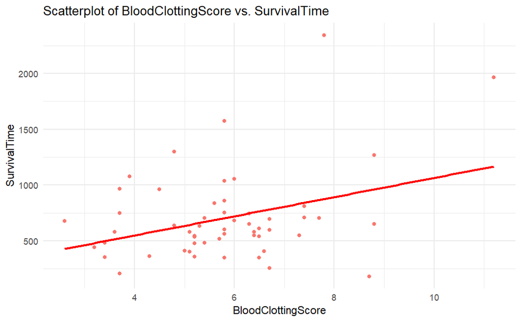

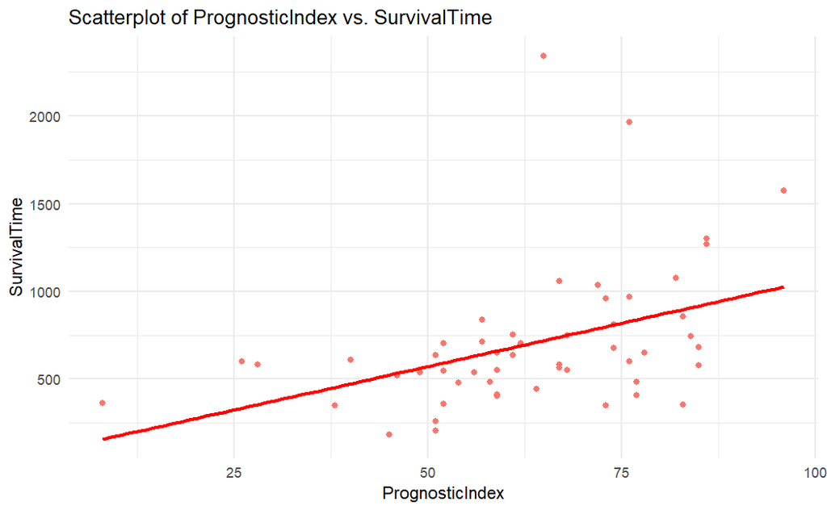

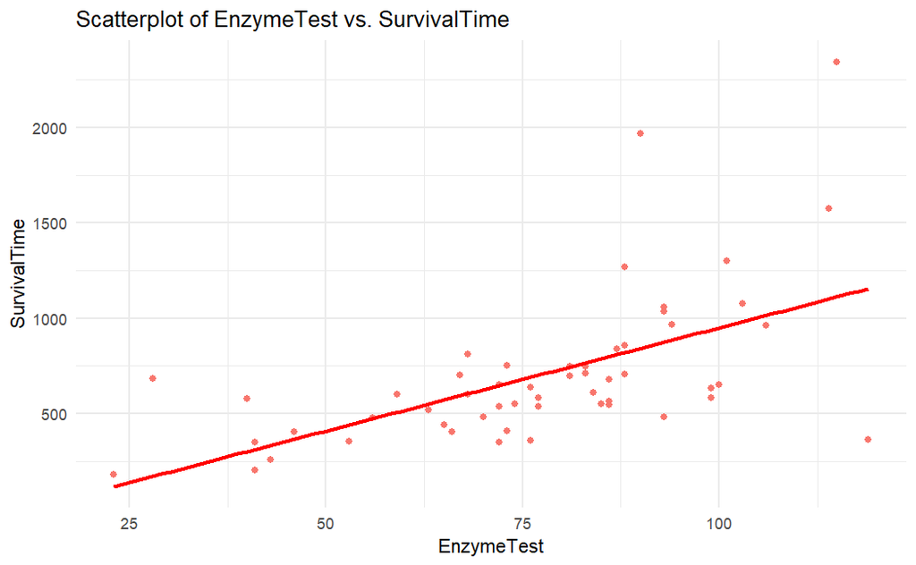

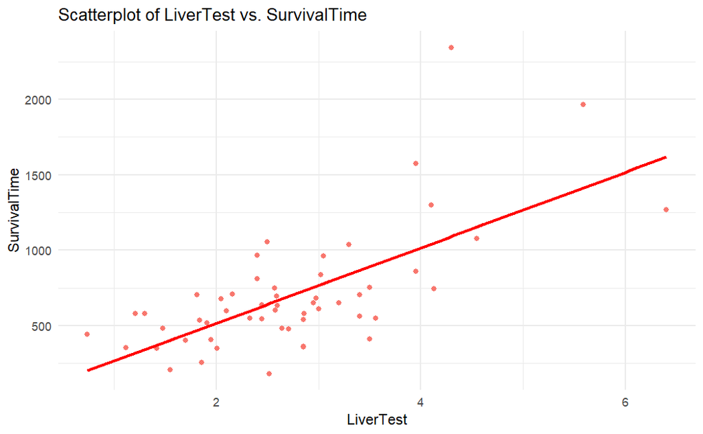

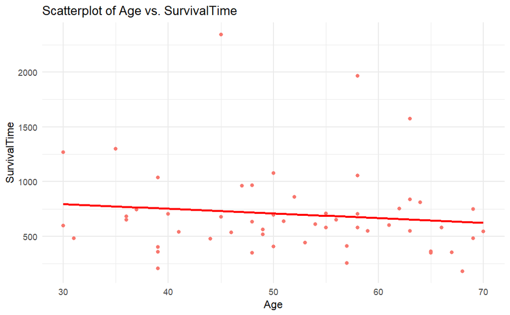

```r
# Load necessary libraries
library(ggplot2)
library(dplyr)
library(tidyr)

# Scatterplots for each quantitative predictor against SurvivalTime
features <- colnames(surgery_quantonly)[-1]  # Exclude the response variable

plots <- list()
for (feature in features) {
  p <- ggplot(surgery_quantonly, aes_string(x = feature, y = "SurvivalTime")) +
    geom_point(aes(color = feature)) +
    geom_smooth(method = "lm", se = FALSE, color = "red") +
    labs(title = paste("Scatterplot of", feature, "vs. SurvivalTime"),
         x = feature,
         y = "SurvivalTime") +
    theme_minimal() +
    theme(legend.position = "none")
  plots[[feature]] <- p
}

# Display plots
plots
```

> From the scatterplot of `PrognosticIndex vs. SurvivalTime`“`, we observe a clear **positive correlation** between the Prognostic Index and Survival Time. As the Prognostic Index score increases, the Survival Time seems to follow. This suggests that the Prognostic Index might be a significant predictor of survival time. Combining this observation with the previous EDA, among all the factors studied, **BloodClottingScore, EnzymeTest, LiverTest, and PrognosticIndex** demonstrate positive associations with SurvivalTime. Conversely, Age doesn’t exhibit a strong predictive relationship, which seems to be negative relationship.

**TASK 3.1.2** Perform meaningful EDA for relating the categorical predictors to the response, and comment on what you observe.

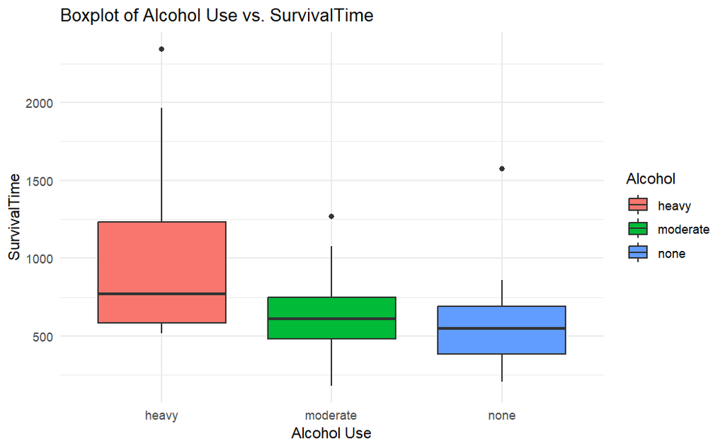

```r
## EDA - look at response with categorical predictors



# Boxplot for Alcohol vs. SurvivalTime
p2 <- ggplot(surgery_data, aes(x = Alcohol, y = SurvivalTime)) +
  geom_boxplot(aes(fill = Alcohol)) +
  labs(title = "Boxplot of Alcohol Use vs. SurvivalTime",
       x = "Alcohol Use",
       y = "SurvivalTime") +
  theme_minimal()

print(p2)
```

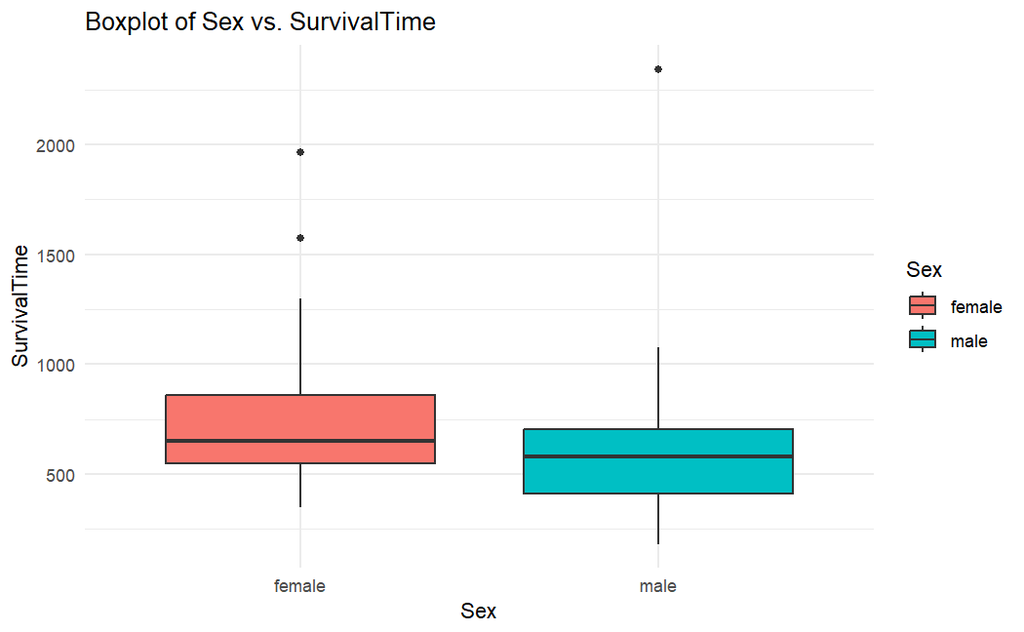

```r
# Boxplot for Sex vs. SurvivalTime
p3 <- ggplot(surgery_data, aes(x = Sex, y = SurvivalTime)) +
  geom_boxplot(aes(fill = Sex)) +
  labs(title = "Boxplot of Sex vs. SurvivalTime",
       x = "Sex",
       y = "SurvivalTime") +
  theme_minimal()

print(p3)
```

### 3.2 - research question 1:

Is the prognostic index alone useful for predicting survival time?

**TASK 3.2.1** Perform meaningful EDA specifically in the context of this first research question, and comment on what you observe.

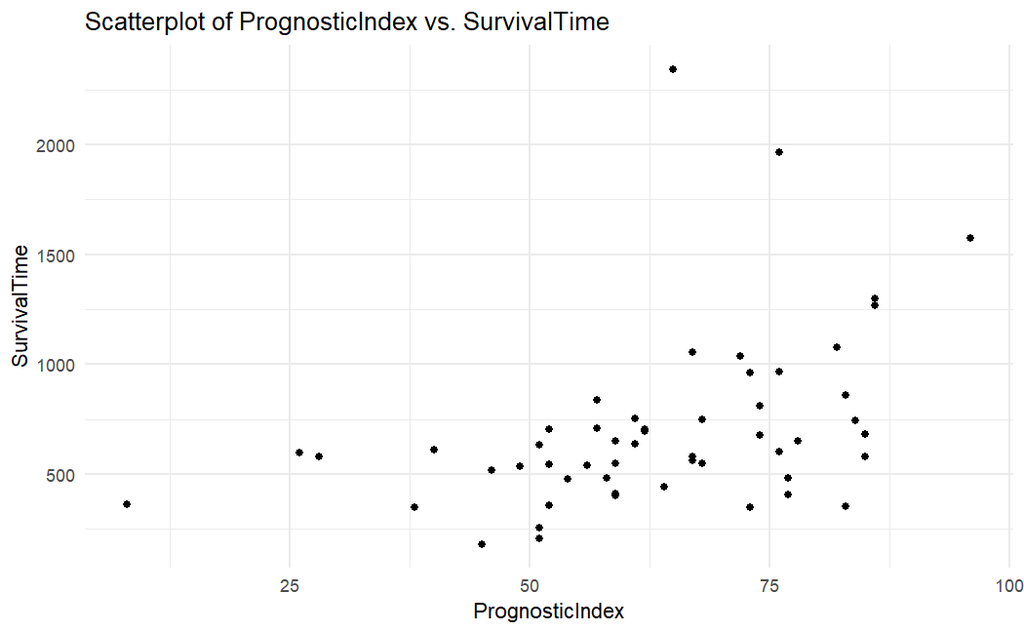

```r
# EDA for first research question
library(ggplot2)

# Scatterplot of PrognosticIndex vs. SurvivalTime
p1 <- ggplot(surgery_data, aes(x = PrognosticIndex, y = SurvivalTime)) +
  geom_point() +
  labs(title = "Scatterplot of PrognosticIndex vs. SurvivalTime",
       x = "PrognosticIndex",
       y = "SurvivalTime") +
  theme_minimal()

print(p1)
```

```r
NA
NA
```

**TASK 3.2.2** What test/model do you choose to answer the research question? Do you have any reasons to worry about whether this test/model is valid? (you should assess the conditions)

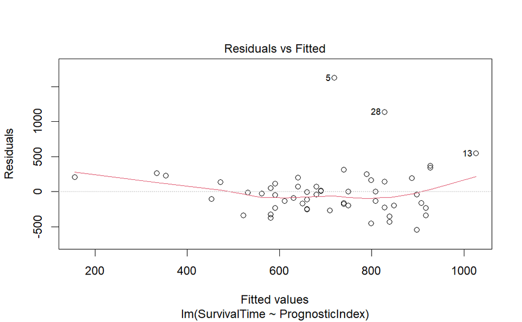

```r
# Now fit the model for the first research question
# Fit a linear regression model for the first research question
model1 <- lm(SurvivalTime ~ PrognosticIndex, data = surgery_data)

# Check residuals for normality and equal variance
plot(model1, which=1) # Residuals vs Fitted
```

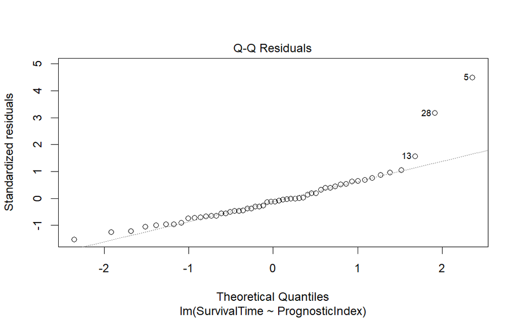

```r
plot(model1, which=2) # Normal Q-Q plot
```

```r
summary(model1)
```

```
Call:
lm(formula = SurvivalTime ~ PrognosticIndex, data = surgery_data)

Residuals:
    Min      1Q  Median      3Q     Max
-544.43 -220.96  -41.18  139.49 1623.52

Coefficients:
                Estimate Std. Error t value Pr(>|t|)
(Intercept)       76.914    193.518   0.397  0.69266
PrognosticIndex    9.886      2.958   3.342  0.00155 **
---
Signif. codes:  0 ‘***’ 0.001 ‘**’ 0.01 ‘*’ 0.05 ‘.’ 0.1 ‘ ’ 1

Residual standard error: 364 on 52 degrees of freedom
Multiple R-squared:  0.1768,    Adjusted R-squared:  0.161
F-statistic: 11.17 on 1 and 52 DF,  p-value: 0.001547
```

> The linear regression model was used to explore the relationship between `SurvivalTime` and `PrognosticIndex`. However, the Residuals vs. Fitted plot hints at potential non-linearity and heteroscedasticity, and the Q-Q plot shows slight deviations at the tails, indicating potential non-normality of residuals. These observations raise concerns about the model’s validity, suggesting that assumptions of linearity, homoscedasticity, and normality might not be fully met.

**TASK 3.2.3** Decide whether you need to perform a transformation and explain your choice. If you choose to do so, then re-fit the model and re-assess the conditions.

> Upon examining the initial model’s diagnostic plots, deviations from linearity and homoscedasticity became apparent. To address these, a logarithmic transformation of the `SurvivalTime` was applied. This transformation, often used to stabilize variance and improve model assumptions, seemed to present a more linear relationship in the transformed scatterplot. The decision to adopt this transformation stemmed from observed breaches of the linear regression assumptions. By utilizing the log-transformed response, the aim is to both satisfy the model’s conditions and enhance its overall validity.

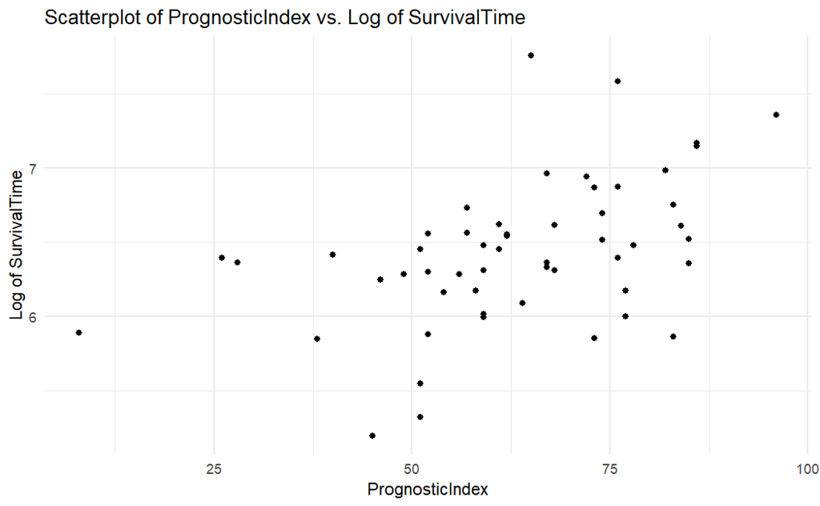

```r
# try graphing log(y) vs x to visualize a model using a log transformation

p2 <- ggplot(surgery_data, aes(x = PrognosticIndex, y = log(SurvivalTime))) +
  geom_point() +
  labs(title = "Scatterplot of PrognosticIndex vs. Log of SurvivalTime",
       x = "PrognosticIndex",
       y = "Log of SurvivalTime") +
  theme_minimal()

print(p2)
```

```r
# If the transformation looks appropriate, re-fit the model
model2 <- lm(log(SurvivalTime) ~ PrognosticIndex, data = surgery_data)
summary(model2)
```

```
Call:
lm(formula = log(SurvivalTime) ~ PrognosticIndex, data = surgery_data)

Residuals:
    Min      1Q  Median      3Q     Max
-0.9827 -0.2068  0.0511  0.2786  1.3046

Coefficients:
                Estimate Std. Error t value Pr(>|t|)
(Intercept)     5.565919   0.232840  23.904  < 2e-16 ***
PrognosticIndex 0.013672   0.003559   3.841 0.000334 ***
---
Signif. codes:  0 ‘***’ 0.001 ‘**’ 0.01 ‘*’ 0.05 ‘.’ 0.1 ‘ ’ 1

Residual standard error: 0.438 on 52 degrees of freedom
Multiple R-squared:  0.221, Adjusted R-squared:  0.2061
F-statistic: 14.76 on 1 and 52 DF,  p-value: 0.0003343
```

**TASK 3.2.4** Use your model to answer the research question in context. > The PrognosticIndex is a statistically significant predictor of the logarithm of SurvivalTime, with every one-unit increase in the PrognosticIndex leading to an approximate 0.013672 unit increase in the natural logarithm of SurvivalTime. This suggests a multiplicative relationship between the two. However, the PrognosticIndex only accounts for about 22.1% of the variability in SurvivalTime, indicating other factors also influence outcomes.

### 3.3 - Research questions 2 and 3:

2. Is the prognostic index useful after accounting for other potentially related predictors?
3. Which factors impact survival time after a liver operation, and how?

These two research questions are linked, in that both of them require you to choose a multiple regression model and then use it.

**TASK 3.3.1** Fit a full first-order model with all variables (including both Sex and Alcohol).

```r
full_model <- lm(SurvivalTime ~ BloodClottingScore + PrognosticIndex + EnzymeTest + LiverTest + Age + Sex + Alcohol, data = surgery_data)
summary(full_model)
```

```
Call:
lm(formula = SurvivalTime ~ BloodClottingScore + PrognosticIndex +
    EnzymeTest + LiverTest + Age + Sex + Alcohol, data = surgery_data)

Residuals:
    Min      1Q  Median      3Q     Max
-285.36 -132.75  -10.00   89.48  790.12

Coefficients:
                   Estimate Std. Error t value Pr(>|t|)
(Intercept)        -812.252    260.618  -3.117 0.003183 **
BloodClottingScore   62.390     24.470   2.550 0.014258 *
PrognosticIndex       8.973      1.874   4.788 1.86e-05 ***
EnzymeTest            9.888      1.742   5.677 9.39e-07 ***
LiverTest            50.413     44.959   1.121 0.268109
Age                  -0.951      2.649  -0.359 0.721231
Sexmale             -15.874     58.475  -0.271 0.787269
Alcoholmoderate    -312.984     78.468  -3.989 0.000242 ***
Alcoholnone        -320.697     85.070  -3.770 0.000474 ***
---
Signif. codes:  0 ‘***’ 0.001 ‘**’ 0.01 ‘*’ 0.05 ‘.’ 0.1 ‘ ’ 1

Residual standard error: 201.4 on 45 degrees of freedom
Multiple R-squared:  0.7818,    Adjusted R-squared:  0.7431
F-statistic: 20.16 on 8 and 45 DF,  p-value: 1.607e-12
```

**TASK 3.3.2** Do you have any concerns about multicollinearity? Justify your answer.

```r
vif(full_model)
```

```
BloodClottingScore    PrognosticIndex         EnzymeTest          LiverTest
          2.009804           1.310682           1.789967           3.024861
               Age            Sexmale    Alcoholmoderate        Alcoholnone
          1.133617           1.131391           2.037354           1.932190
```

> Multicollinearity is a concern in regression analysis when two or more predictor variables are highly correlated, which can affect the reliability of coefficient estimates. The Variance Inflation Factor (VIF) is a common metric to assess multicollinearity. Generally, a VIF exceeding 10 indicates high multicollinearity. Analyzing the VIF values from the provided `full_model`, all predictors have VIF values well below 10. Specifically, the highest VIF is for `LiverTest` at 3.024861, which is still relatively low. Therefore, based on these VIF values, there are no serious concerns about multicollinearity in the model.

**TASK 3.3.3** Assess the conditions for your model. If you have any concerns that would be solved by a transformation, perform the transformation and re-fit the model.

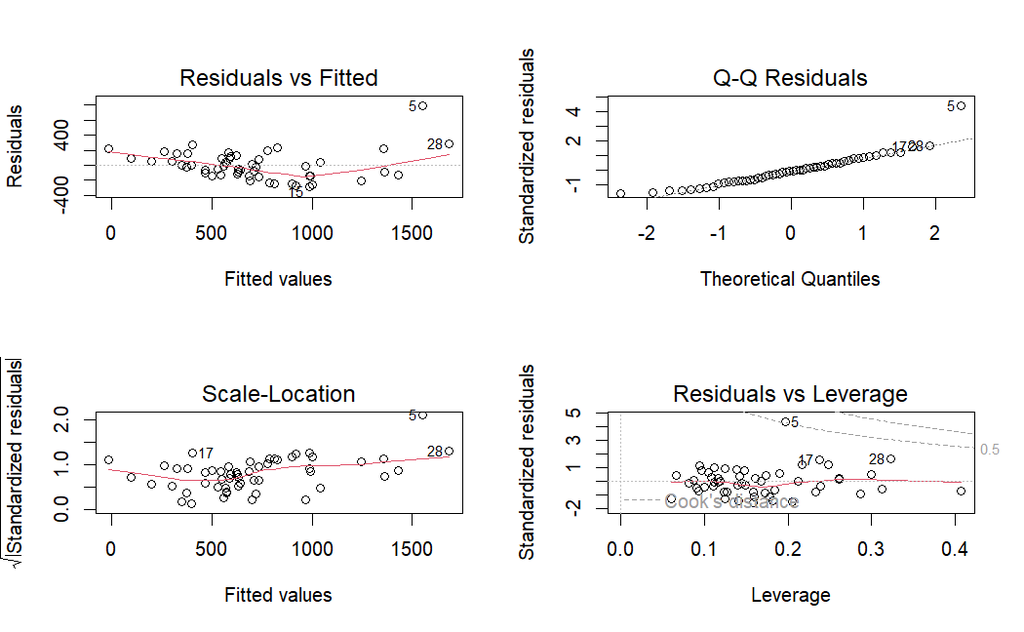

```r
par(mfrow=c(2,2))
plot(full_model)
```

**TASK 3.3.4** How many of the terms in your model are significant?

> From the regression output, five predictors:`BloodClottingScore, PrognosticIndex, EnzymeTest, Alcoholmoderate, and Alcoholnone` are statistically significant at the 5% level. The other variables, namely LiverTest, Age, and Sexmale, aren’t significant. Thus, out of eight predictors, five significantly influence SurvivalTime after a liver operation.

**TASK 3.3.5** Use a variable selection method (best subsets, forward selection, backwards elimination, or stepwise regression) to choose a model and report which variables are included.

```r
step_model <- stepAIC(full_model, direction = "backward")
```

```
Start:  AIC=581.14
SurvivalTime ~ BloodClottingScore + PrognosticIndex + EnzymeTest +
    LiverTest + Age + Sex + Alcohol

                     Df Sum of Sq     RSS    AIC
- Sex                 1      2990 1828896 579.23
- Age                 1      5231 1831137 579.30
- LiverTest           1     51016 1876922 580.63
<none>                            1825906 581.14
- BloodClottingScore  1    263780 2089686 586.43
- Alcohol             2    726901 2552807 595.24
- PrognosticIndex     1    930187 2756093 601.38
- EnzymeTest          1   1307757 3133663 608.31

Step:  AIC=579.23
SurvivalTime ~ BloodClottingScore + PrognosticIndex + EnzymeTest +
    LiverTest + Age + Alcohol

                     Df Sum of Sq     RSS    AIC
- Age                 1      4603 1833499 577.37
- LiverTest           1     62577 1891474 579.05
<none>                            1828896 579.23
- BloodClottingScore  1    260927 2089823 584.43
- Alcohol             2    723911 2552807 593.24
- PrognosticIndex     1    928195 2757091 599.40
- EnzymeTest          1   1304777 3133673 606.31

Step:  AIC=577.37
SurvivalTime ~ BloodClottingScore + PrognosticIndex + EnzymeTest +
    LiverTest + Alcohol

                     Df Sum of Sq     RSS    AIC
<none>                            1833499 577.37
- LiverTest           1     79610 1913109 577.66
- BloodClottingScore  1    257600 2091100 582.47
- Alcohol             2    752340 2585839 591.94
- PrognosticIndex     1    923607 2757106 597.40
- EnzymeTest          1   1323413 3156913 604.71
```

```r
summary(step_model)
```

```
Call:
lm(formula = SurvivalTime ~ BloodClottingScore + PrognosticIndex +
    EnzymeTest + LiverTest + Alcohol, data = surgery_data)

Residuals:
    Min      1Q  Median      3Q     Max
-302.16 -130.68   -6.86   95.72  785.80

Coefficients:
                   Estimate Std. Error t value Pr(>|t|)
(Intercept)        -860.176    230.334  -3.734 0.000508 ***
BloodClottingScore   59.887     23.305   2.570 0.013410 *
PrognosticIndex       8.914      1.832   4.866 1.32e-05 ***
EnzymeTest            9.753      1.674   5.824 4.96e-07 ***
LiverTest            57.976     40.584   1.429 0.159749
Alcoholmoderate    -316.184     75.748  -4.174 0.000128 ***
Alcoholnone        -320.895     83.124  -3.860 0.000345 ***
---
Signif. codes:  0 ‘***’ 0.001 ‘**’ 0.01 ‘*’ 0.05 ‘.’ 0.1 ‘ ’ 1

Residual standard error: 197.5 on 47 degrees of freedom
Multiple R-squared:  0.7809,    Adjusted R-squared:  0.753
F-statistic: 27.92 on 6 and 47 DF,  p-value: 6.216e-14
```

> Based on the stepwise regression using AIC as the criterion, the final model selected includes the predictors: BloodClottingScore, PrognosticIndex, EnzymeTest, LiverTest, and Alcohol. The other variables were removed as they did not significantly contribute to the model according to the stepwise selection process.

**TASK 3.3.6** Assess the conditions for the model you chose in part 3.3.5 and comment.

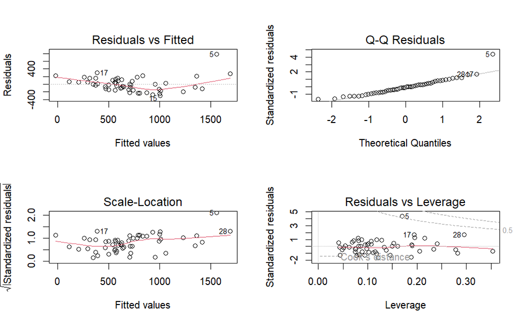

```r
par(mfrow=c(2,2))
plot(step_model)
```

> Based on the diagnostic plots, the model exhibits minor non-linearity and potential heteroscedasticity. While residuals appear approximately normal, a few data points might be influential. Addressing these concerns, such as considering transformations or examining influential points, could enhance model robustness.

**TASK 3.3.7** Answer the second research question in context using what you learned from the model fitting above.

> The PrognosticIndex proves to be a pivotal predictor for survival time following liver surgery, maintaining its significance even amidst the inclusion of various predictors. Both the full model and the stepwise regression model underscore its statistical significance, thereby highlighting its substantial influence on SurvivalTime. The PrognosticIndex not only stands out as a vital individual predictor but also retains its predictive power within a multifaceted model, encompassing numerous variables.

**TASK 3.3.8** Answer the third research question, in context.

> The survival time post-liver operation is intricately influenced by several factors, with BloodClottingScore, PrognosticIndex, EnzymeTest, and Alcohol emerging as pivotal from the regression models. BloodClottingScore and EnzymeTest, indicative of physiological health, alongside PrognosticIndex, offer a nuanced insight into the patient’s health status and potential recovery trajectory. Additionally, Alcohol, reflecting lifestyle choices, also significantly sways survival time, underscoring the multifaceted nature of post-operative recovery.